# Time series models

Barry Quinn

## Learning outcomes

- Stationary and differencing
- Modelling stationary time series
- ARIMA models (liner model)
- Categories of algorithms in capital markets
- Algorithmic ARIMA modelling
- Practical example with some of the project data

## Stationarity and differencing

- The foundation of statistical inference in time series analysis is the concept of weak stationarity.
- roughly horizontal
- constant variance
- no patterns predictable in the long-term

Are these financial time series stationary?

[figure not shown]

```r
tsfe::indices %>%
  select(date,`RUSSELL 2000 - PRICE INDEX`) %>%
  rename(r2000=`RUSSELL 2000 - PRICE INDEX`) %>%
  drop_na() %>%
  tq_transmute(select =r2000,mutate_fun = periodReturn,type='log') ->monthly_r2002r
  ts(monthly_r2002r$monthly.returns, start = c(1988,1))->r2000r_m_ts
  autoplot(r2000r_m_ts) + ylab("Log returns") + xlab("Year") + labs(title="Figure 2: Monthly log returns of the Russell 2000 Price Index",subtitle =" from March 1988 to December 2019")
```

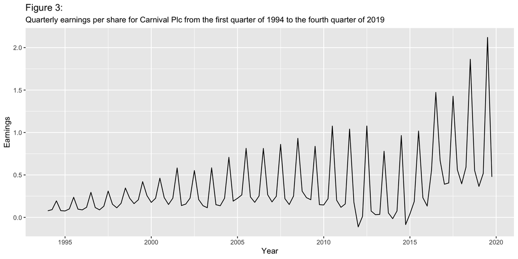

```r
autoplot(tsfe::carnival_eps_ts) + xlab("Year") + ylab("Earnings") +
  labs(title="Figure 3:",subtitle =  "Quarterly earnings per share for Carnival Plc from the first quarter of 1994 to the fourth quarter of 2019")
```

## Inference and stationarity

- The monthly log returns of Russell 2000 index vary around zero over time.
  - If we divide up the data into subperiods we would expect each sample mean to be roughly zero.
- Furthermore, expect the recent financial crisis (2007-2009), the log returns range is approximately [-0.2,0.2].
- Statistically, the mean and the variance are constant over time OR time invariant.
- Put together these to time invariant properties characterise a weakly stationary series.

## Weak stationarity and prediction

- Weak form stationarity provides a basic framework for prediction.
- For the monthly log returns of the Russell 2000 we can predict with reasonable confidence:
- Future monthly returns $\approx0$ and vary $[-0.2,0.2]$

## Inference and nonstationarity

- Consider quarterly earnings for Carnival Plc.

```r
library(fpp2)
tsfe::carnival_eps_ts |> autoplot()
```

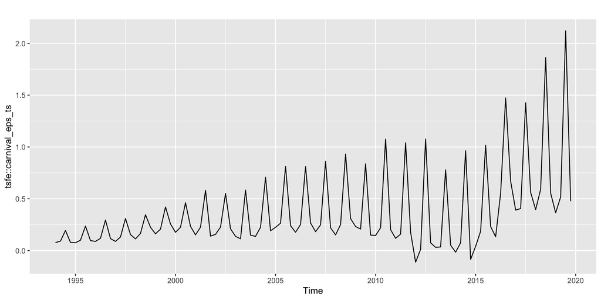

## Inference and nonstationarity

- If the timespan is divided into subperiods the sample mean and variance for each period show increasing pattern.
- Earnings are **not** weakly stationary.
- There does exist models and methods for modelling such nonstationary series.

## Is the VIX time series Stationary?

```r
tq_get('^VIX') %>%
  ggplot(aes(x=date,y=adjusted)) +
  ylab("VIX") + geom_line()
```

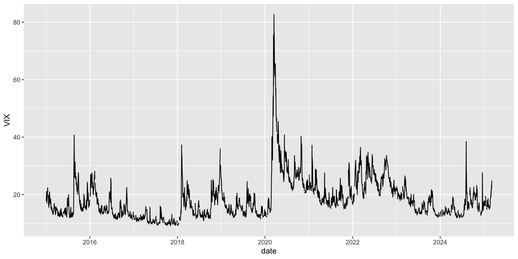

## Non-stationarity in the mean

- Identifying non-stationary series:
- time plot.
- The ACF of stationary data drops to zero relatively quickly
- The ACF of non-stationary data decreases slowly.
- For non-stationary data, the value of $r_1$ is often large and positive.

## Example: FTSE index

```r
autoplot(ftse_m_ts) + ylab("Monthly Price Index") + xlab("Year")
```

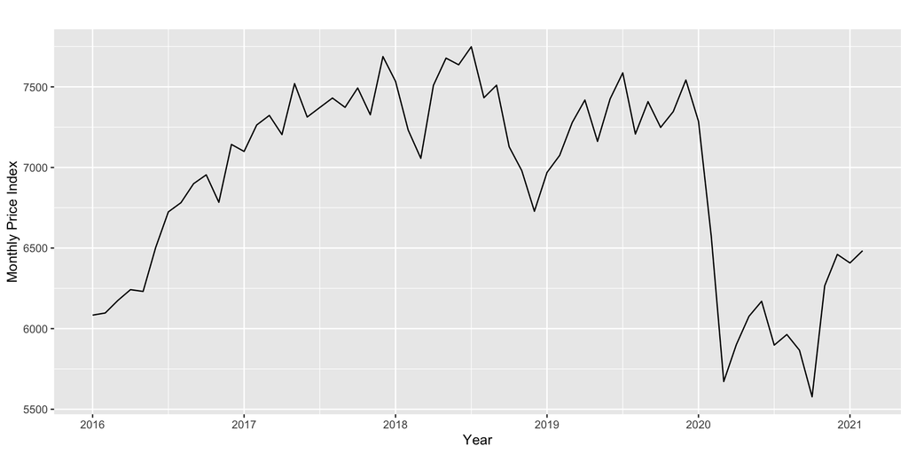

## ACF

```r
ggAcf(ftse_m_ts)
```

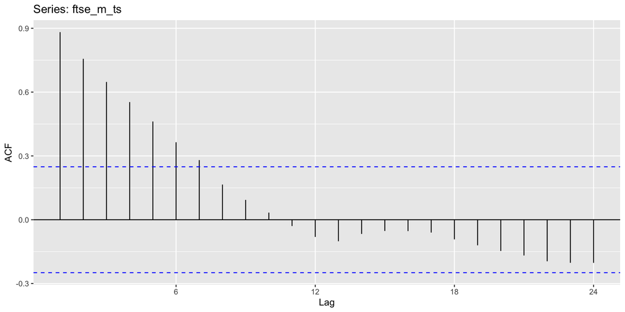

## First differencing

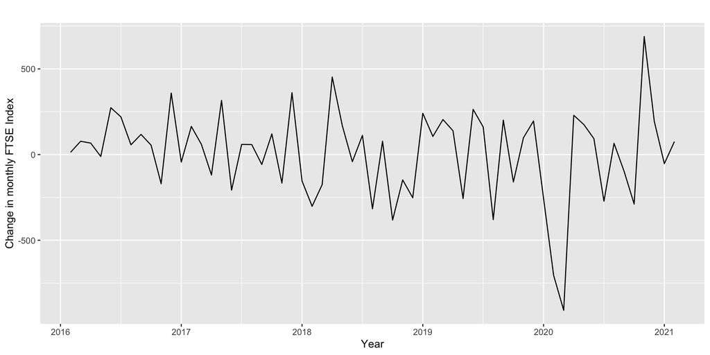

```r
autoplot(diff(ftse_m_ts)) + ylab("Change in monthly FTSE Index") + xlab("Year")
```

### ACF after first differencing

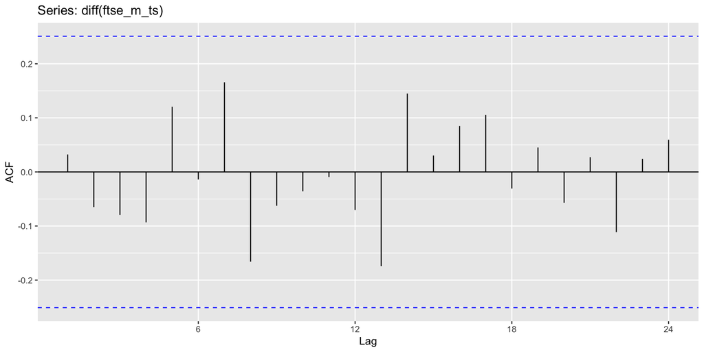

```r
ggAcf(diff(ftse_m_ts))
```

## Differencing

- Differencing helps to **stabilize the mean**.
- The differenced series is the *change* between each observation in the original series: ${y'_t = y_t - y_{t-1}}$.
- The differenced series will have only $T-1$ values since it is not possible to calculate a difference $y_1'$ for the first observation.

## Financial ratio example

### subset using `window()`

```r
window(carnival_eps_ts,end=c(2010,1)) %>% autoplot()
```

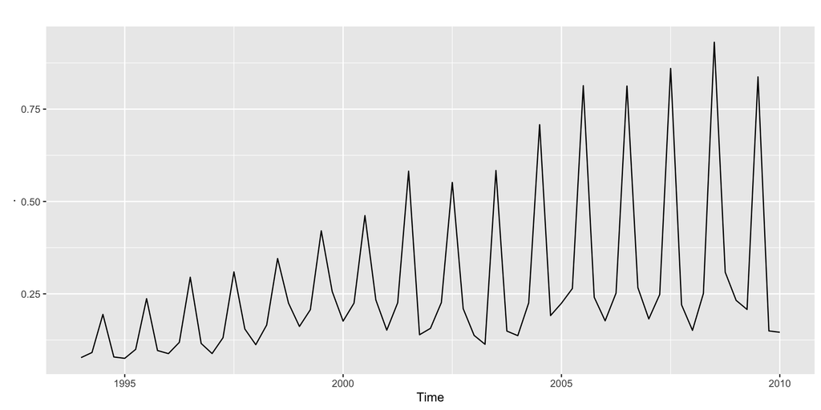

## use `log()` to stablise variation

```r
window(carnival_eps_ts,end=c(2010,1)) %>% log() %>% autoplot()
```

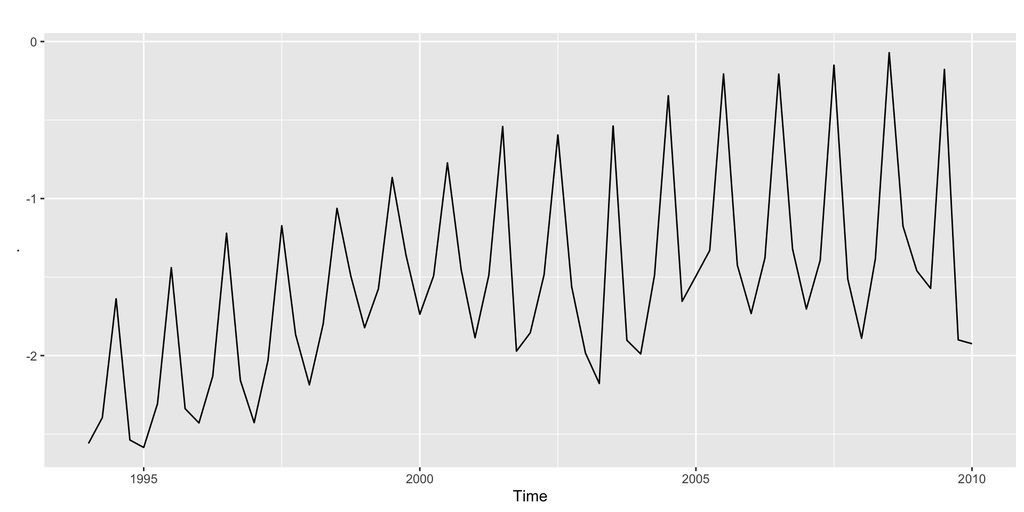

## Seasonally differencing?

```r
window(carnival_eps_ts,end=c(2010,1)) %>%
  log() %>% diff(lag=4) %>%  autoplot()
```

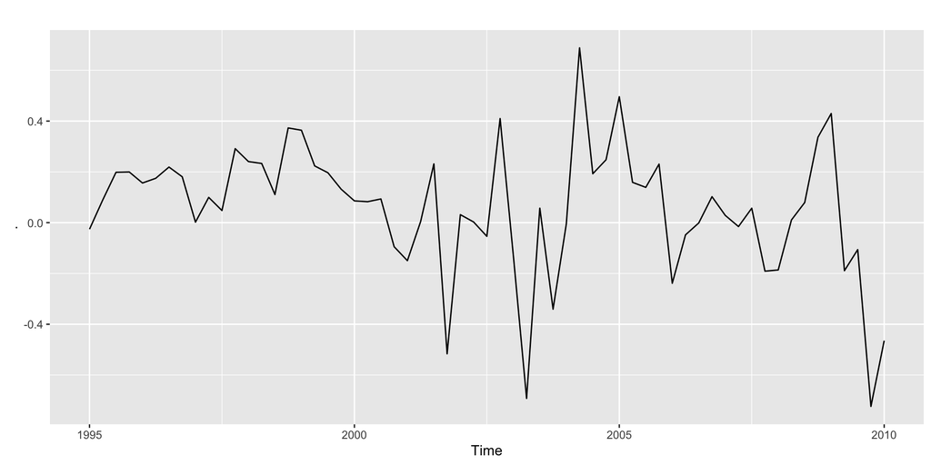

## Is this now stationary

```r
window(carnival_eps_ts,end=c(2010,1)) %>% log() %>% diff(lag=4) %>% diff(lag=1) %>% autoplot()
```

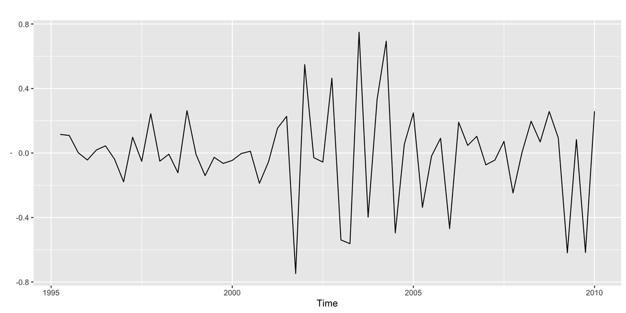

## Interpretation of differencing

- first differences are the change between **one observation and the next**;
- seasonal differences are the change between **one year to the next**.
- But taking lag 3 differences for yearly data, for example, results in a model which cannot be sensibly interpreted.

## Unit root tests

> Statistical tests to determine the required order of differencing
1. Augmented Dickey Fuller test: null hypothesis is that the data are non-stationary and non-seasonal.
2. Kwiatkowski-Phillips-Schmidt-Shin (KPSS) test: null hypothesis is that the data are stationary and non-seasonal.
3. Other tests available for seasonal data.

## KPSS test

```r
library(urca)
summary(ur.kpss(ftse_m_ts))
```

```
#######################
# KPSS Unit Root Test #
#######################

Test is of type: mu with 3 lags.

Value of test-statistic is: 0.3983

Critical value for a significance level of:
                10pct  5pct 2.5pct  1pct
critical values 0.347 0.463  0.574 0.739
```

## Automatically selecting differences

- Seasonal strength $F_s = \max\big(0, 1-\frac{\text{Var}(R_t)}{\text{Var}(S_t+R_t)}\big)$
- If $F_s > 0.64$, do one seasonal difference.

```r
carnival_eps_ts %>% log() %>% nsdiffs()
```

```
[1] 1
```

```r
carnival_eps_ts %>% log() %>% diff(lag=4) %>% ndiffs()
```

```
[1] 0
```

## Non-seasonal ARIMA models

#### Autoregressive models

- When $y_t$ has a statistically significant lag-1 autocorrelation, the lagged value $y_{t-1}$ might be a useful in predicting $y_t$.
- AR(1) model

$$y_{t}= c+\phi_{1}y_{t - 1} + \varepsilon_{t}$$

- where $\varepsilon_t$ is white noise.
- This is a simple linear regression with **lagged values** of $y_t$ as predictors.
- This simple model is widely used in stochastic volatility when $y_t$ is replaced by its log volatility.

## Autoregressive models

- More generally, if the $E(y_{t-1})$ is determined by more than lag-1 we can generalise a AR(1) to an AR(p) model.
- $$y_{t}= c+\phi_{1}y_{t - 1}+\phi_{2}y_{t - 2} + \dots +\phi_{p}y_{t - p} + \varepsilon_{t},$$
  where $\varepsilon_t$ is white noise.
- This is a multiple linear regression with **lagged values** of $y_t$ as predictors.

## Example of an AR(1) model

```r
set.seed(1)
autoplot(10 + arima.sim(list(ar = -0.8), n = 100)) +
  ylab("") + ggtitle("AR(1)")
```

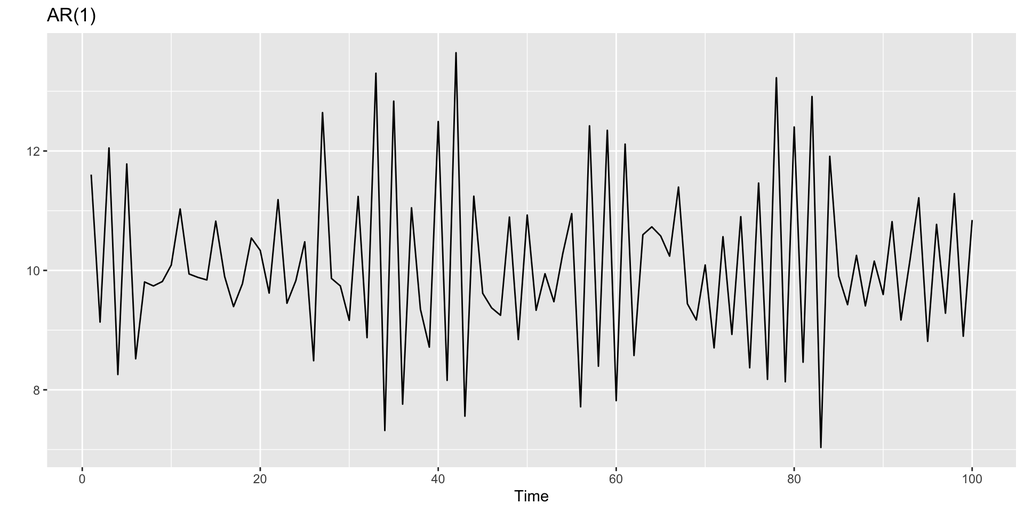

## Simulating an AR(2)

- Simulating an $y_t = 8 + 1.3y_{t-1} - 0.7 y_{t-2} + \varepsilon_t$
- where $\varepsilon_t\sim N(0,1)$ for $T=100$.

```r
set.seed(1)
autoplot(20 + arima.sim(list(ar = c(1.3, -0.7)), n = 100)) + ylab("") + ggtitle("AR(2)")
```

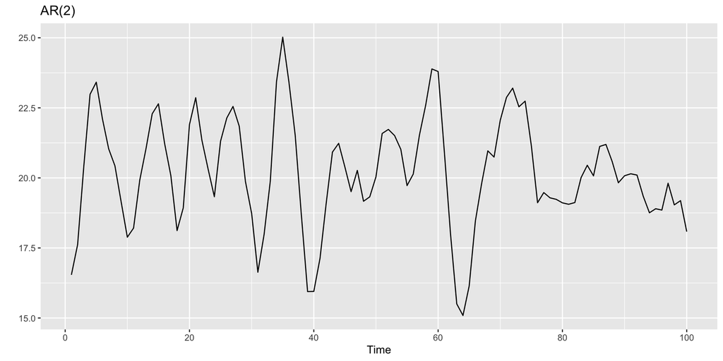

## AR(1) models explained

$$y_{t}=c + \phi_1 y_{t -1}+\varepsilon_{t}$$
When $\phi_1=0$, $y_t$ is **equivalent to White Noise**

When $\phi_1=1$ and $c=0$, $y_t$ is **equivalent to a Random Walk**

When $\phi_1=1$ and $c\ne0$, $y_t$ is **equivalent to a Random Walk with drift**

When $\phi_1<0$, $y_t$ tends to **oscillate between positive and negative values**.

## Moving Average (MA) models

- Moving Average (MA) models:

$$y_{t} =c +\varepsilon_t + \theta_{1}\varepsilon_{t - 1} + \theta_{2}\varepsilon_{t - 2} +\cdots+\theta_{q}\varepsilon_{t - q},$$

where $\varepsilon_t$ is white noise. - This is a multiple regression with **past errors** as predictors. **Don’t confuse this with moving average smoothing!**